# LDA

###Load Libaries

```r
library(MASS)
library(ggplot2)
```

###Set Working Directory

```r
setwd("/Users/erinweaver/Documents/GitHub/TheThreeMusketeers/")
```

###Import Data Set

```r
wineqt <- read.csv("/Users/erinweaver/Documents/GitHub/TheThreeMusketeers/Data/WineQT.csv")
head(wineqt)
```

```
##   fixed.acidity volatile.acidity citric.acid residual.sugar chlorides
## 1           7.4             0.70        0.00            1.9     0.076
## 2           7.8             0.88        0.00            2.6     0.098
## 3           7.8             0.76        0.04            2.3     0.092
## 4          11.2             0.28        0.56            1.9     0.075
## 5           7.4             0.70        0.00            1.9     0.076
## 6           7.4             0.66        0.00            1.8     0.075
##   free.sulfur.dioxide total.sulfur.dioxide density   pH sulphates alcohol
## 1                  11                   34  0.9978 3.51      0.56     9.4
## 2                  25                   67  0.9968 3.20      0.68     9.8
## 3                  15                   54  0.9970 3.26      0.65     9.8
## 4                  17                   60  0.9980 3.16      0.58     9.8
## 5                  11                   34  0.9978 3.51      0.56     9.4
## 6                  13                   40  0.9978 3.51      0.56     9.4
##   quality Id
## 1       5  0
## 2       5  1
## 3       5  2
## 4       6  3
## 5       5  4
## 6       5  5
```

###Wrangle to Key Variables

```r
wine_wrangled <- wineqt[, c(2,5,8,9,12)]
head(wine_wrangled)
```

```
##   volatile.acidity chlorides density   pH quality
## 1             0.70     0.076  0.9978 3.51       5
## 2             0.88     0.098  0.9968 3.20       5
## 3             0.76     0.092  0.9970 3.26       5
## 4             0.28     0.075  0.9980 3.16       6
## 5             0.70     0.076  0.9978 3.51       5
## 6             0.66     0.075  0.9978 3.51       5
```

###View Structure of Dataset

```r
str(wine_wrangled)
```

```
## 'data.frame':    1143 obs. of  5 variables:
##  $ volatile.acidity: num  0.7 0.88 0.76 0.28 0.7 0.66 0.6 0.65 0.58 0.58 ...
##  $ chlorides       : num  0.076 0.098 0.092 0.075 0.076 0.075 0.069 0.065 0.073 0.097 ...
##  $ density         : num  0.998 0.997 0.997 0.998 0.998 ...
##  $ pH              : num  3.51 3.2 3.26 3.16 3.51 3.51 3.3 3.39 3.36 3.28 ...
##  $ quality         : int  5 5 5 6 5 5 5 7 7 5 ...
```

###Set Quality to Factor

```r
wine_wrangled$quality = factor(wine_wrangled$quality, levels = c("3", "4", "5", "6", "7", "8"), ordered = TRUE)
```

###View Structure of Dataset

```r
str(wine_wrangled)
```

```
## 'data.frame':    1143 obs. of  5 variables:
##  $ volatile.acidity: num  0.7 0.88 0.76 0.28 0.7 0.66 0.6 0.65 0.58 0.58 ...
##  $ chlorides       : num  0.076 0.098 0.092 0.075 0.076 0.075 0.069 0.065 0.073 0.097 ...
##  $ density         : num  0.998 0.997 0.997 0.998 0.998 ...
##  $ pH              : num  3.51 3.2 3.26 3.16 3.51 3.51 3.3 3.39 3.36 3.28 ...
##  $ quality         : Ord.factor w/ 6 levels "3"<"4"<"5"<"6"<..: 3 3 3 4 3 3 3 5 5 3 ...
```

*** STOP SIGN ***

###Scale each predictor variable:

```r
wine_wrangled[1:4] <- scale(wine_wrangled[1:4])
```

###Find the mean of each predictor variable:

```r
apply(wine_wrangled[1:4], 2, mean)
```

```
## volatile.acidity        chlorides          density               pH
##     1.739349e-15     5.735667e-15    -3.460706e-13    -1.220255e-14
```

###Find standard deviation of each predictor variable:

```r
apply(wine_wrangled[1:4], 2, sd)
```

```
## volatile.acidity        chlorides          density               pH
##                1                1                1                1
```

###Make this example reproducible:

```r
set.seed(1)
```

###Use 70% of dataset as training set and remaining 30% as testing set

```r
sample <- sample(c(TRUE, FALSE), nrow(wine_wrangled), replace=TRUE, prob=c(0.7,0.3))
train <- wine_wrangled[sample, ]
test <- wine_wrangled[!sample, ]
```

###Fit LDA model

```r
model <- lda(quality~., data=train)
```

###View model output

```r
model
```

```
## Call:
## lda(quality ~ ., data = train)
##
## Prior probabilities of groups:
##       3       4       5       6       7       8
## 0.00375 0.03500 0.41000 0.40375 0.13875 0.00875
##
## Group means:
##   volatile.acidity   chlorides     density          pH
## 3        1.6162274  0.57969628  0.75127534 -0.13413972
## 4        0.9389212 -0.17689181 -0.07423699  0.60219472
## 5        0.3060258  0.06676452  0.17778146 -0.05006982
## 6       -0.1265455 -0.02660845 -0.06272600  0.08146231
## 7       -0.7517112 -0.20746900 -0.24422054 -0.17324330
## 8       -0.2619386 -0.41867761 -0.73859231 -0.56271828
##
## Coefficients of linear discriminants:
##                          LD1         LD2        LD3         LD4
## volatile.acidity -0.98724052  0.18916601 -0.4664482 -0.07840115
## chlorides        -0.16585074 -0.05781727  0.6957015 -0.99078930
## density          -0.33540027 -0.01726327  0.7285571  0.74287367
## pH               -0.09262148 -1.06106451  0.4185101  0.07261674
##
## Proportion of trace:
##    LD1    LD2    LD3    LD4
## 0.8629 0.0804 0.0517 0.0050
```

###Store Model Means

```r
modelmeans <- model$means
```

###Convert Matrix to Data Frame

```r
modelmeans <- as.data.frame(modelmeans)
str(modelmeans)
```

```
## 'data.frame':    6 obs. of  4 variables:
##  $ volatile.acidity: num  1.616 0.939 0.306 -0.127 -0.752 ...
##  $ chlorides       : num  0.5797 -0.1769 0.0668 -0.0266 -0.2075 ...
##  $ density         : num  0.7513 -0.0742 0.1778 -0.0627 -0.2442 ...
##  $ pH              : num  -0.1341 0.6022 -0.0501 0.0815 -0.1732 ...
```

###Convert row labels to column

```r
library(tibble)
modelmeans <- tibble::rownames_to_column(modelmeans, "quality")
```

# Plot Means

### Melt Dataframe

```r
library(reshape2)
mmodelmeans <- melt(modelmeans, id.vars="quality")
```

### Everything on the same plot

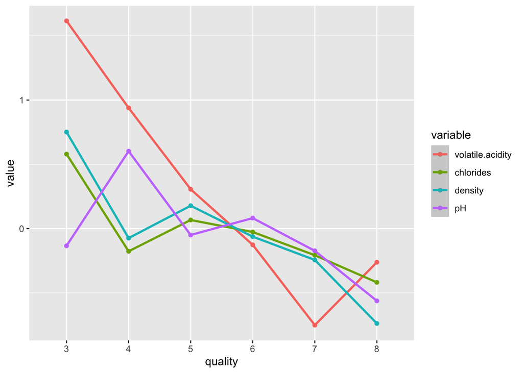

```r
ggplot(mmodelmeans, aes(quality, value, group=variable, col=variable)) +
  geom_line() +
  geom_point() +
  stat_smooth()
```

### Separate plots

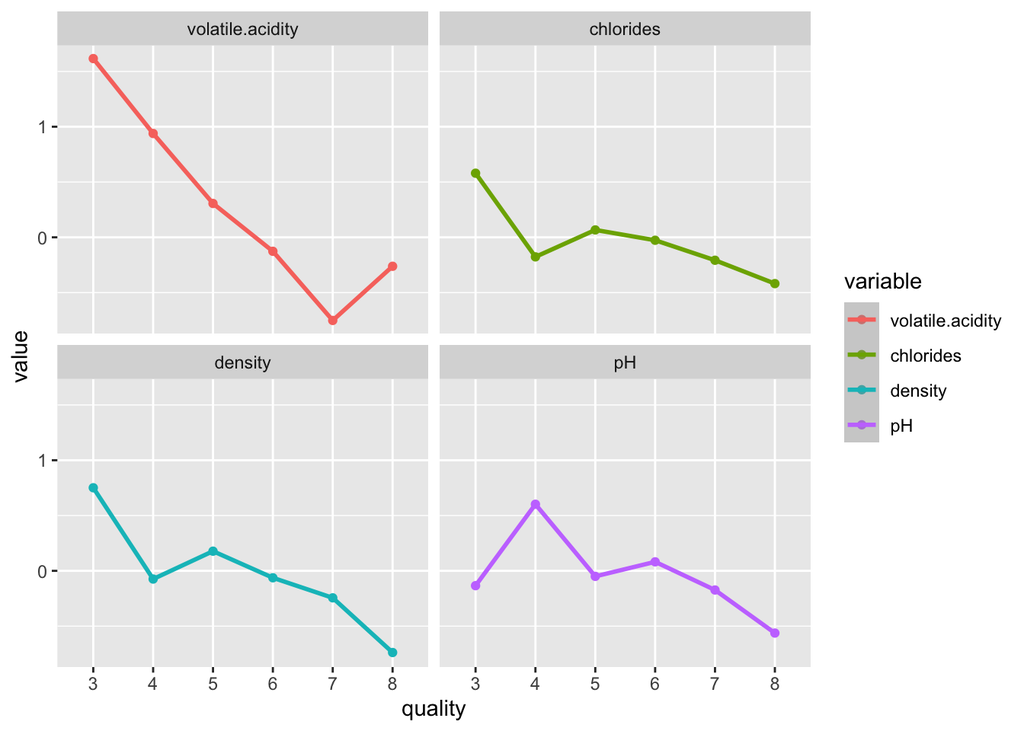

```r
ggplot(mmodelmeans, aes(quality, value, group=variable, col=variable)) +
  geom_point() +
  stat_smooth() +
  facet_wrap(~variable)
```

```r
#lda.pred = (test$class)
#lda.error = mean(default$default != lda.pred)
#lda.error
```

```r
#LDA_model = lda.cm
#LDA_model
```

###Use LDA model to make predictions on test data

```r
predicted <- predict(model, test)
```

###View predicted class for first six observations in test set

```r
head(predicted$class)
```

```
## [1] 6 5 5 6 5 6
## Levels: 3 4 5 6 7 8
```

###View posterior probabilities for first six observations in test set

```r
head(predicted$posterior)
```

```
##               3           4         5         6          7            8
## 4  5.447785e-05 0.003475051 0.2565498 0.4301147 0.30296603 0.0068399848
## 6  1.987033e-03 0.073402627 0.4912910 0.3942343 0.03847096 0.0006141343
## 7  8.915412e-04 0.031148641 0.4676033 0.4060456 0.08754223 0.0067686941
## 15 1.416444e-04 0.017983603 0.3067431 0.5451008 0.12954337 0.0004875773
## 17 4.426605e-04 0.011806595 0.4147467 0.4146365 0.14686400 0.0115036090
## 18 1.175394e-04 0.013746531 0.2949952 0.5243992 0.16488502 0.0018565266
```

###View linear discriminants for first six observations in test set

```r
head(predicted$x)
```

```
##           LD1        LD2        LD3        LD4
## 4   1.2974723  0.7632667  0.5639303 0.75481104
## 6  -0.9630362 -1.2052765  0.4364889 0.67401211
## 7  -0.2441581  0.1737348 -0.5868537 0.18837569
## 15  0.4206838 -1.5694830  1.4187161 0.80411739
## 17  0.3149221  0.9164348 -0.2763403 0.01606496
## 18  0.6523267 -0.9405094  0.6666388 0.15489907
```

```r
#mean(predicted$class==test$quality)
```

###Define data to plot

```r
lda_plot <- cbind(train, predict(model)$x)
```

###Create plot

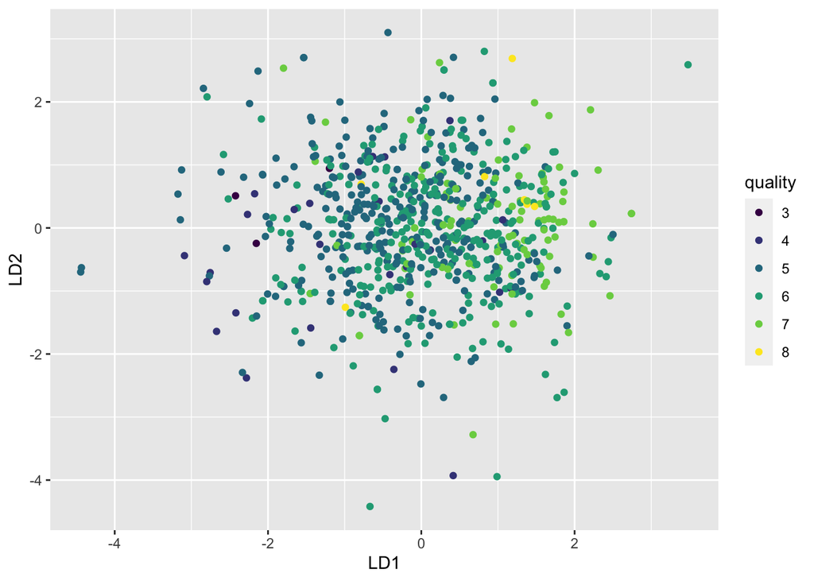

```r
ggplot(lda_plot, aes(LD1, LD2, LD3, LD4)) +
  geom_point(aes(color = quality))
```

# Identify Outliers

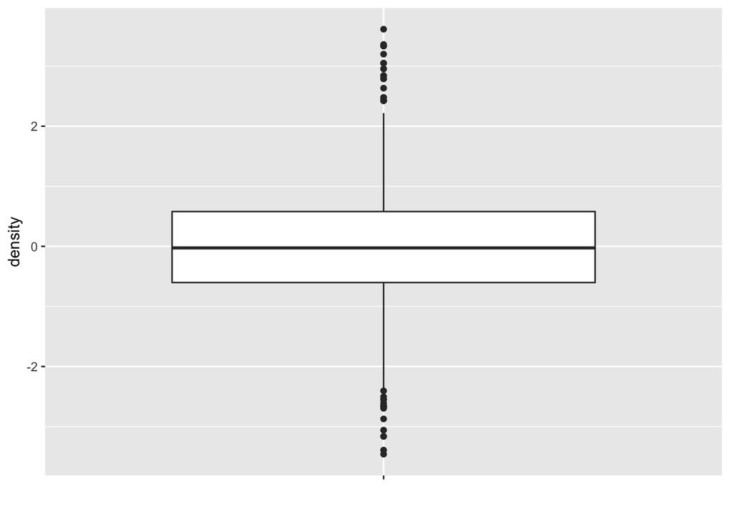

```r
bp.density <- ggplot(wine_wrangled, aes(x = "", y = density)) + geom_boxplot() + xlab("")
bp.density
```

```r
# numerous outliers present (36)
# view outliers ($out)
boxplot.stats(wine_wrangled$density)
```

```
## $stats
## [1] -2.35337829 -0.60278999 -0.02618672  0.57898698  2.21789086
##
## $n
## [1] 1143
##
## $conf
## [1] -0.08141602  0.02904257
##
## $out
##  [1] -2.665056 -2.665056  2.425676  2.477622  2.477622  2.633461 -2.872841
##  [8]  2.841246  2.841246  2.425676  2.425676  3.360708  3.049031  2.425676
## [15]  3.334735  3.334735  2.789300  2.789300 -2.613109  3.049031 -2.405325
## [22] -2.696223 -3.163740 -3.163740  3.199675 -2.654666 -3.459833 -3.392303
## [29] -2.680640 -3.059847 -2.504022  3.615245  2.955527 -2.550774  2.955527
## [36] -2.550774
```

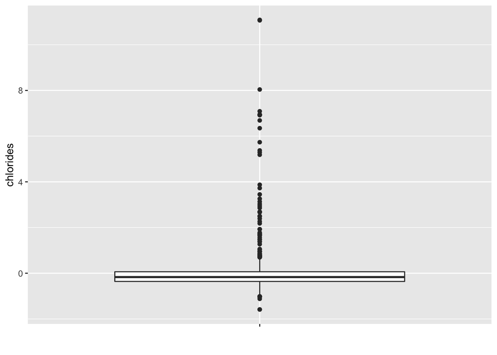

```r
bp.chlorides <- ggplot(wine_wrangled, aes(x = "", y = chlorides)) + geom_boxplot() + xlab("")
bp.chlorides
```

```r
# numerous outliers present (77)
# view outliers ($out)
boxplot.stats(wine_wrangled$chlorides)
```

```
## $stats
## [1] -0.9717626 -0.3582312 -0.1678248  0.0648940  0.6784255
##
## $n
## [1] 1143
##
## $conf
## [1] -0.1875992 -0.1480505
##
## $out
##  [1]  5.3751148  5.1847085  8.0408033  1.9266447 11.0661482  3.8730205
##  [7] -1.0140752  5.2904897  3.7249266 11.0873045  5.7347712  2.6671137
## [13]  2.6882700  0.7207380  0.8688318  0.6995817  0.7418943  0.7418943
## [19]  0.7207380  0.8476755  1.3765820  0.8053630  0.7418943  2.3920824
## [25]  2.9421451  3.4498953  0.7842068  2.8575201 -1.0140752  1.4823633
## [31]  7.0887717 -1.1198565  6.3483026  6.9406779  1.4823633  3.2594890
## [37]  2.1805198  0.9534568  0.8265193 -1.0352314  1.6516134  1.2708007
## [43] -1.5852941 -1.5852941  2.2651448  0.9534568  1.5669883  0.6995817
## [49]  0.6995817  0.7630505  0.7630505  6.9195216  1.7785509  1.9266447
## [55]  1.6727696  1.0380819  0.9534568  0.9534568  0.7630505  0.7630505
## [61]  6.6868028  1.0592381  6.9195216  1.6727696  1.7150821  6.9406779
## [67]  1.3977383  6.9406779  0.7630505  2.6882700  1.7362384  2.4978637
## [73]  2.4978637 -1.0140752  3.1325514  3.0267701 -1.0352314
```

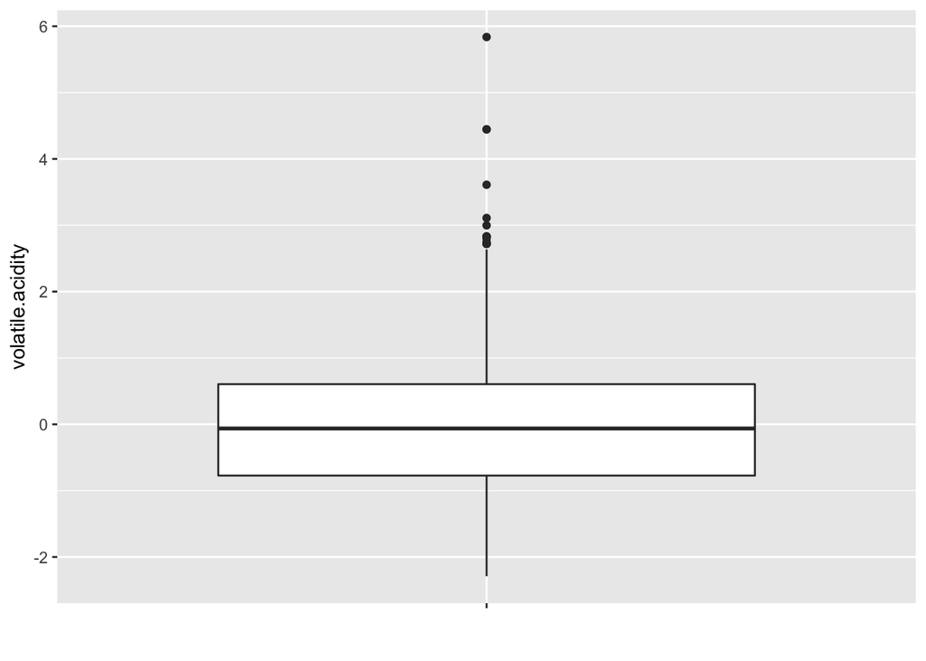

```r
bp.volatile.acidity <- ggplot(wine_wrangled, aes(x = "", y = volatile.acidity)) + geom_boxplot() + xlab("")
bp.volatile.acidity
```

```r
# numerous outliers present (14)
# view outliers ($out)
boxplot.stats(wine_wrangled$volatile.acidity)
```

```
## $stats
## [1] -2.28988070 -0.77290049 -0.06312075  0.60490723  2.63682569
##
## $n
## [1] 1143
##
## $conf
## [1] -0.127511371  0.001269862
##
## $out
##  [1] 2.720329 2.998674 4.446068 4.446068 2.831667 3.110012 2.831667 2.720329
##  [9] 2.803833 2.748164 2.720329 5.837793 3.611033 2.831667
```

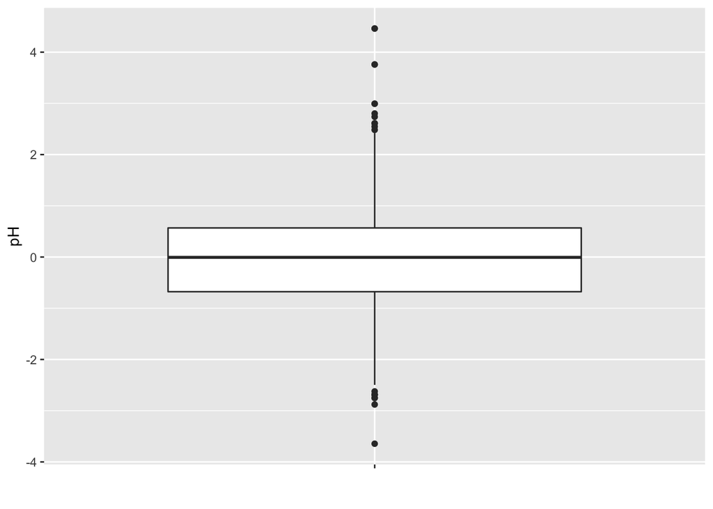

```r
bp.ph <- ggplot(wine_wrangled, aes(x = "", y = pH)) + geom_boxplot() + xlab("")
bp.ph
```

```r
# numerous outliers present (20)
# view outliers ($out)
boxplot.stats(wine_wrangled$pH)
```

```
## $stats
## [1] -2.495881147 -0.676701940 -0.006478021  0.567999623  2.419094254
##
## $n
## [1] 1143
##
## $conf
## [1] -0.06464804  0.05169200
##
## $out
##  [1]  3.759542  2.802079 -3.644836 -2.751205 -2.878866  2.738249  2.610587
##  [8] -2.687374 -2.687374  3.759542  2.546756 -2.687374  2.993572  2.482925
## [15]  2.993572  4.461681 -2.623543  4.461681 -2.751205  2.610587
```

Graphing The Relationship with Quality

```r
aggregate(x = wine_wrangled$volatile.acidity, by = list(wine_wrangled$quality), FUN = mean)
```

```
##   Group.1          x
## 1       3  2.0383839
## 2       4  0.9389212
## 3       5  0.3002837
## 4       6 -0.1468652
## 5       7 -0.7663798
## 6       8 -0.6754797
```

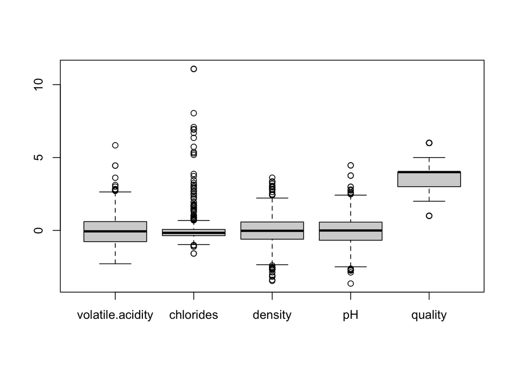

```r
boxplot(wine_wrangled)
```

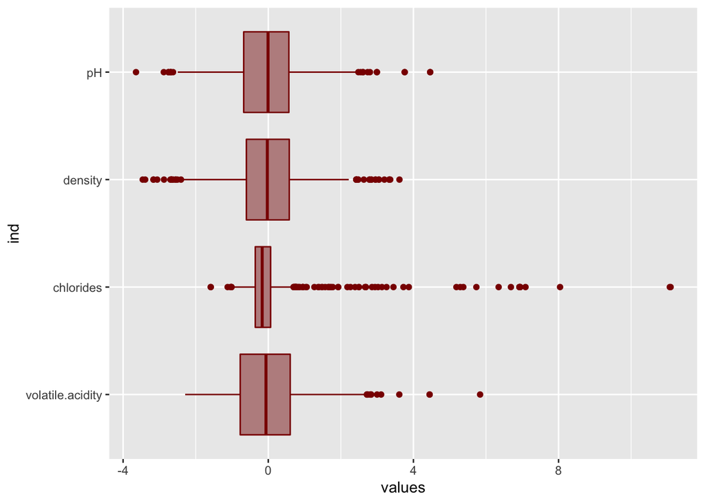

```r
ggplot(stack(wine_wrangled), aes(x = ind, y = values))+
  geom_boxplot(fill='rosybrown', color="darkred") +
  coord_flip()
```

REMOVE CHLORIDE OUTLIERS (77)

```r
chloride.Q1 <- quantile(wine_wrangled$chlorides, .25)
chloride.Q3 <- quantile(wine_wrangled$chlorides, .75)
chloride.IQR <- IQR(wine_wrangled$chlorides)
```

```r
no.chlorides.outliers <- subset(wine_wrangled, wine_wrangled$chlorides > (chloride.Q1 - 1.5*chloride.IQR) & wine_wrangled$chlorides < (chloride.Q3 + 1.5*chloride.IQR))
```

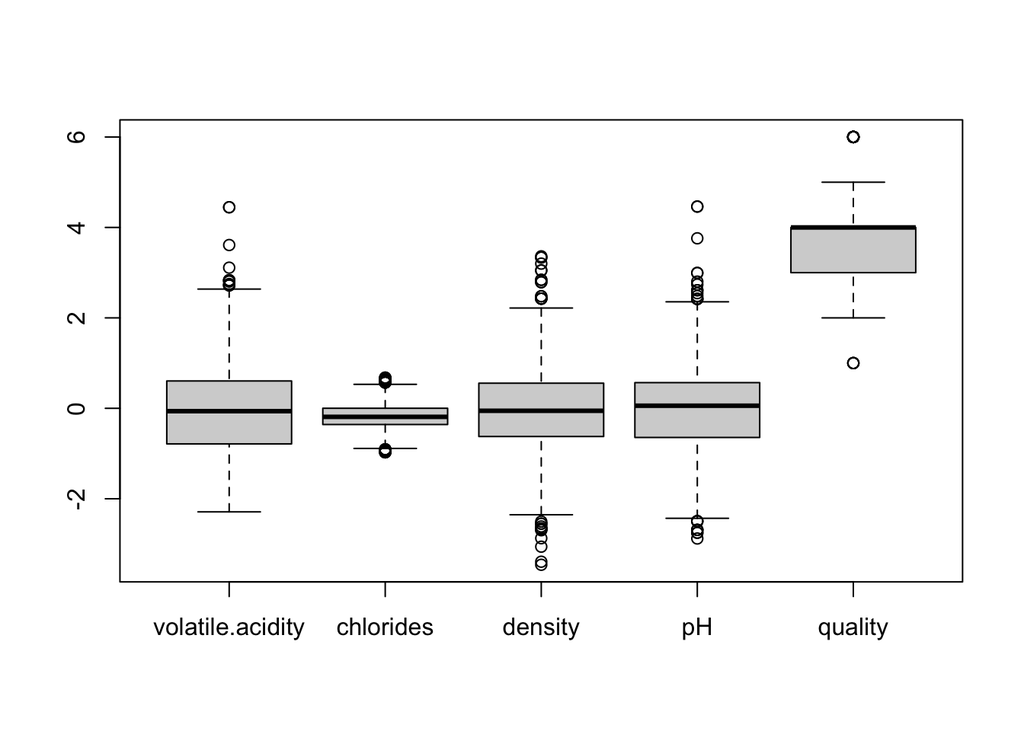

```r
boxplot(no.chlorides.outliers)
```

RECHECK OUTLIER COUNT:

```r
boxplot.stats(no.chlorides.outliers$pH)
```

```
## $stats
## [1] -2.43205030 -0.64478652  0.05735283  0.56799962  2.35526340
##
## $n
## [1] 1066
##
## $conf
## [1] -0.001336983  0.116042639
##
## $out
##  [1]  3.759542  2.802079  2.419094  2.419094 -2.751205 -2.878866  2.738249
##  [8] -2.495881 -2.495881  2.610587 -2.687374 -2.687374 -2.495881  2.546756
## [15]  2.419094 -2.687374  2.993572  2.482925  2.993572  4.461681  4.461681
## [22] -2.751205  2.610587
```

```r
# outlier count - (23)
```

```r
boxplot.stats(no.chlorides.outliers$volatile.acidity)
```

```
## $stats
## [1] -2.28988070 -0.78681774 -0.06312075  0.60490723  2.63682569
##
## $n
## [1] 1066
##
## $conf
## [1] -0.130469871  0.004228362
##
## $out
##  [1] 2.720329 4.446068 4.446068 2.831667 3.110012 2.831667 2.720329 2.803833
##  [9] 2.748164 2.720329 3.611033 2.831667
```

```r
# outlier count - (12)
```

```r
boxplot.stats(no.chlorides.outliers$density)
```

```
## $stats
## [1] -2.35337829 -0.62356849 -0.05475715  0.55561117  2.21789086
##
## $n
## [1] 1066
##
## $conf
## [1] -0.111820662  0.002306353
##
## $out
##  [1] -2.665056 -2.665056  2.425676  2.477622  2.477622 -2.872841  2.841246
##  [8]  2.841246  2.425676  2.425676  3.360708  3.049031  2.425676  3.334735
## [15]  3.334735  2.789300  2.789300 -2.613109  3.049031 -2.696223  3.199675
## [22] -2.654666 -3.459833 -3.392303 -2.680640 -3.059847 -2.504022 -2.550774
## [29] -2.550774
```

```r
# outlier count - (29)
```

REMOVE DENSITY OUTLIERS (29)

```r
density_Q1 <- quantile(no.chlorides.outliers$density, .25)
density_Q3 <- quantile(no.chlorides.outliers$density, .75)
density_IQR <- IQR(no.chlorides.outliers$density)
```

```r
no_outliers_cd <- subset(no.chlorides.outliers, no.chlorides.outliers$density > (density_Q1 - 1.5*density_IQR) & no.chlorides.outliers$density < (density_Q3 + 1.5*density_IQR))
```

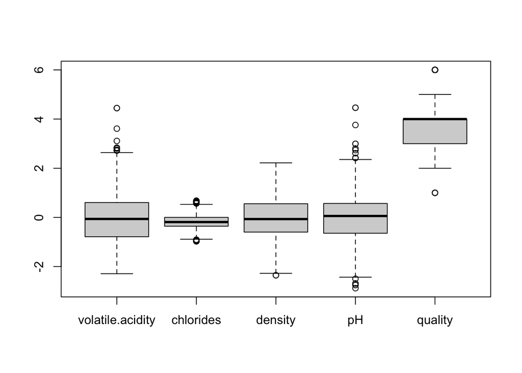

```r
boxplot(no_outliers_cd)
```

RECOUNT OUTLIERS

```r
boxplot.stats(no_outliers_cd$volatile.acidity)
```

```
## $stats
## [1] -2.28988070 -0.78681774 -0.06312075  0.60490723  2.63682569
##
## $n
## [1] 1037
##
## $conf
## [1] -0.131405096  0.005163587
##
## $out
##  [1] 2.720329 4.446068 4.446068 2.831667 3.110012 2.831667 2.720329 2.803833
##  [9] 2.748164 2.720329 3.611033 2.831667
```

```r
# outlier count - (12)
```

```r
boxplot.stats(no_outliers_cd$pH)
```

```
## $stats
## [1] -2.43205030 -0.64478652  0.05735283  0.56799962  2.35526340
##
## $n
## [1] 1037
##
## $conf
## [1] -0.002151963  0.116857619
##
## $out
##  [1]  3.759542  2.802079  2.419094  2.419094 -2.751205 -2.878866  2.738249
##  [8] -2.687374 -2.687374 -2.495881  2.419094  2.993572  2.993572  4.461681
## [15]  4.461681 -2.751205  2.610587
```

```r
# outlier count - (17)
```

RUN MODEL AGAIN